# Ishan'sProject

Part 3: Exploratory data analysis

I will start by showing how the temperature changed throughout the years for the United States of America using a scatter plot.

```python
new_df = pd.read_csv("./Data1_1_2022.csv")
new_df1 = new_df.drop(columns = ['Domain', 'Domain Code', 'Element Code', 'Element', 'Months', 'Year Code', 'Unit','Flag','Flag Description'])
new_df1
```

|  | Area Code (FAO) | Area | Months Code | Year | Value |
| --- | --- | --- | --- | --- | --- |
| 0 | 2 | Afghanistan | 7001 | 1961 | 0.746 |
| 1 | 2 | Afghanistan | 7001 | 1962 | 0.009 |
| 2 | 2 | Afghanistan | 7001 | 1963 | 2.695 |
| 3 | 2 | Afghanistan | 7001 | 1964 | -5.277 |
| 4 | 2 | Afghanistan | 7001 | 1965 | 1.827 |
| ... | ... | ... | ... | ... | ... |
| 229920 | 181 | Zimbabwe | 7020 | 2016 | 1.470 |
| 229921 | 181 | Zimbabwe | 7020 | 2017 | 0.443 |
| 229922 | 181 | Zimbabwe | 7020 | 2018 | 0.747 |
| 229923 | 181 | Zimbabwe | 7020 | 2019 | 1.359 |
| 229924 | 181 | Zimbabwe | 7020 | 2020 | 0.820 |

229925 rows × 5 columns

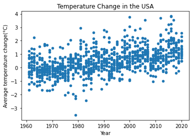

```python
America = new_df1[new_df1['Area Code (FAO)'] ==  231]
America = America.dropna()
fig = America.plot.scatter(x = 'Year',y = 'Value', title="Temperature Change in the USA")
fig.set_ylabel('Average temperature change(°C)')
```

Next, I will be showing how the temperature changed throughout the years for India using a scatter plot.

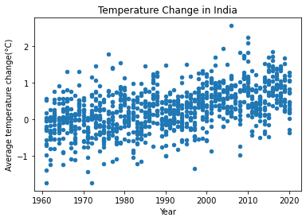

```python
India = new_df1[new_df1['Area Code (FAO)'] ==  100]
India = India.dropna()
fig = India.plot.scatter(x='Year',y='Value', title="Temperature Change in India")
fig.set_ylabel('Average temperature change(°C)')
```

Next, I will be showing how the temperature changed throughout the years for the United Kingdom of Great Britain and Northern Ireland using a scatter plot.

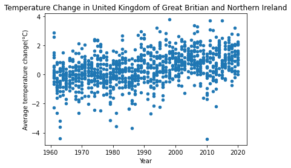

```python
UK = new_df1[new_df1['Area Code (FAO)'] ==  229]
UK = UK.dropna()
fig = UK.plot.scatter(x='Year',y='Value', title="Temperature Change in United Kingdom of Great Britian and Northern Ireland")
fig.set_ylabel('Average temperature change(°C)')
```

Next, I will be showing how the temperature changed throughout the years for China/Hong Kong using a scatter plot.

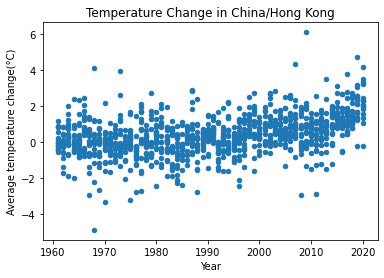

```python
HK = new_df1[new_df1['Area Code (FAO)'] ==  96]
HK = HK.dropna()
fig = HK.plot.scatter(x='Year',y='Value', title="Temperature Change in China/Hong Kong")
fig.set_ylabel('Average temperature change(°C)')
```

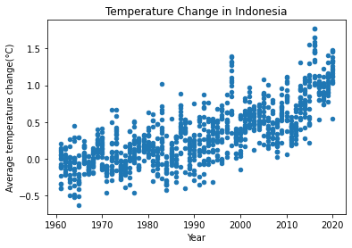

```python
Indonesia = new_df1[new_df1['Area Code (FAO)'] ==  101]
Indonesia = Indonesia.dropna()
fig = Indonesia.plot.scatter(x='Year',y='Value', title="Temperature Change in Indonesia")
fig.set_ylabel('Average temperature change(°C)')
```

Next, I will be showing how the temperature changed throughout the years for Peru using a scatter plot.

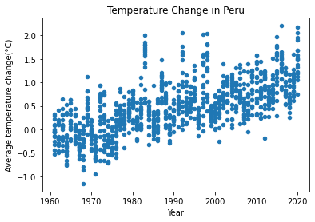

```python
Peru = new_df1[new_df1['Area Code (FAO)'] ==  170]
Peru = Peru.dropna()
fig = Peru.plot.scatter(x='Year',y='Value', title="Temperature Change in Peru")
fig.set_ylabel('Average temperature change(°C)')
```

Next, I will be showing how the temperature changed throughout the years for Egypt using a scatter plot.

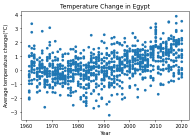

```python
Egypt = new_df1[new_df1['Area Code (FAO)'] ==  59]
Egypt = Egypt.dropna()
fig = Egypt.plot.scatter(x='Year',y='Value', title="Temperature Change in Egypt")
fig.set_ylabel('Average temperature change(°C)')
```

Lastly, I will be showing how the temperature changed throughout the years for South Africa using a scatter plot.

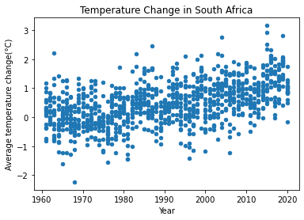

```python
SF = new_df1[new_df1['Area Code (FAO)'] ==  202]
SF = SF.dropna()
fig = SF.plot.scatter(x='Year',y='Value', title="Temperature Change in South Africa")
fig.set_ylabel('Average temperature change(°C)')
```

Hypothesis testing